# Investigación cuantitativa con software gratis

Un flujo de trabajo sencillo: encuesta → datos → análisis → gráficas

Stephen Pitts, S.J. — Marquette University

Trujillo, 21 de agosto de 2026

# Bienvenida

## Qué vamos a hacer esta mañana

**Un solo flujo, de principio a fin — no un tour de programas.**

```
  KoboToolbox  →  celulares  →  archivo CSV  →  RStudio
   (armar)        (recoger)     (descargar)     (analizar)
```

Armar una encuesta, responderla **en vivo** desde sus celulares, descargar las respuestas y analizarlas. Al final de la mañana lo habremos recorrido **una vez completo**, con datos que ustedes mismos generaron.

## Todo es software gratis

| Para qué | Herramienta | Costo |
| --- | --- | --- |
| Armar y recoger la encuesta | **KoboToolbox** | Gratis |
| Analizar y graficar | **R + RStudio** (instalado o en el navegador) | Gratis |

- Nada de licencias, nada que renovar
- Funciona después de que nosotros nos vayamos — esa es la idea

## Lo que necesitan hoy

- Un **celular** con internet — para responder la encuesta
- Una computadora, y hay **dos caminos igual de buenos**:
  - **La del laboratorio** — ya tiene R y RStudio, no hay nada que instalar
  - **La suya**, si la trajeron — la instalamos hoy, y se la llevan funcionando
- Una **cuenta de correo**, solo si quieren llevarse su propia copia (es al final)

## Cómo va a funcionar la mañana

**Una sola encuesta, compartida.** Traigo una armada; la recorremos juntos, le agregamos las preguntas que ustedes quieran, y todos la responden desde su celular. Analizamos **esos** datos — los de esta sala.

**Al final, su propia copia.** Quien quiera se crea una cuenta y se lleva el formulario para adaptarlo a lo suyo.

# 1. Cómo armar una encuesta sencilla

## KoboToolbox: qué es

- Plataforma **gratuita** para encuestas, hecha para trabajo de campo
- Se arma desde el navegador, se responde desde el **celular**
- Funciona **sin internet** en el momento de responder (se sincroniza después)
- Usada por ONGs, ministerios y universidades en todo el mundo

## La terminamos aquí, entre todos

- La encuesta **ya existe** — por eso el QR del cartel funciona desde el primer minuto
- **Le faltan preguntas, y las ponen ustedes:** yo escribo, ustedes dicen qué preguntar
- La volvemos a desplegar y queda lista para responder
- Al final de la mañana verán cómo hacerse **su propia copia**

## Crear un proyecto nuevo

1. **NUEVO** → *Crear desde un borrador*
2. Ponerle nombre: *Encuesta rápida de docentes*
3. **Crear proyecto**

## Así se ve: elegir cómo empezar

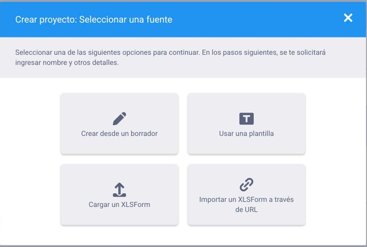

Crear proyecto nuevo

## Agregar preguntas

- **+** para agregar una pregunta
- Escribir el texto de la pregunta
- Elegir el **tipo** de respuesta

## Así se ve: el editor de preguntas

[figure not shown]

Editor de preguntas

## Los tipos de pregunta que más se usan

| Tipo | Para qué sirve | Ejemplo |
| --- | --- | --- |
| *Select One* | Una sola opción | Área que enseña |
| *Select Many* | Varias opciones | Recursos que usa |
| *Number* | Cantidades | Años de experiencia |
| *Text* | Respuesta libre | Comentarios |
| *Rating* | Escala 1–5 | Nivel de acuerdo |

## Cuatro reglas que ahorran horas después

1. **Una pregunta = una idea.** Si tiene una “y”, probablemente son dos preguntas.
2. **Opciones cerradas siempre que se pueda.** Es más fácil contar categorías que leer 40 respuestas libres.
3. **Nombres de variable cortos y sin tildes**: `anios_experiencia`, no `¿Cuántos años…?`
4. **Ábranla en un celular antes de repartirla.** En la computadora se ve bien casi siempre; en el teléfono no siempre.

## Antes de encuestar a sus estudiantes

- **Avisen a la dirección** antes de aplicarla — una encuesta que lleva el nombre del instituto compromete al instituto
- **Digan para qué es** y quién va a ver las respuestas
- **No pidan el nombre** salvo que sepan exactamente por qué lo necesitan
- **Sin nombre se contesta mejor:** el anonimato no es sólo cuidado, es lo que hace que respondan lo que de verdad piensan

⭐ **La de hoy fue así:** no les pidió el nombre a ustedes.

## Nuestra encuesta de práctica

Seis preguntas sobre los docentes en esta sala:

- ¿En qué instituto trabaja?
- ¿Cuántos años lleva enseñando?
- ¿A qué **familia profesional** pertenece?
- ¿Cuántos estudiantes tiene en su aula más grande?
- ¿Cuántos **minutos** demora en llegar al instituto?
- ¿Usa el celular como herramienta en clase?

## Desplegar la encuesta

- **Deploy** — hasta que no se despliega, no recibe respuestas
- Cada cambio posterior requiere **redesplegar**
- Al desplegar aparece el **enlace**

⭐ **¿Y si ya tengo respuestas y me equivoqué en una pregunta?** Se corrige y se vuelve a desplegar: **las respuestas anteriores no se pierden** y el enlace sigue siendo el mismo.

## Así se ve: desplegar

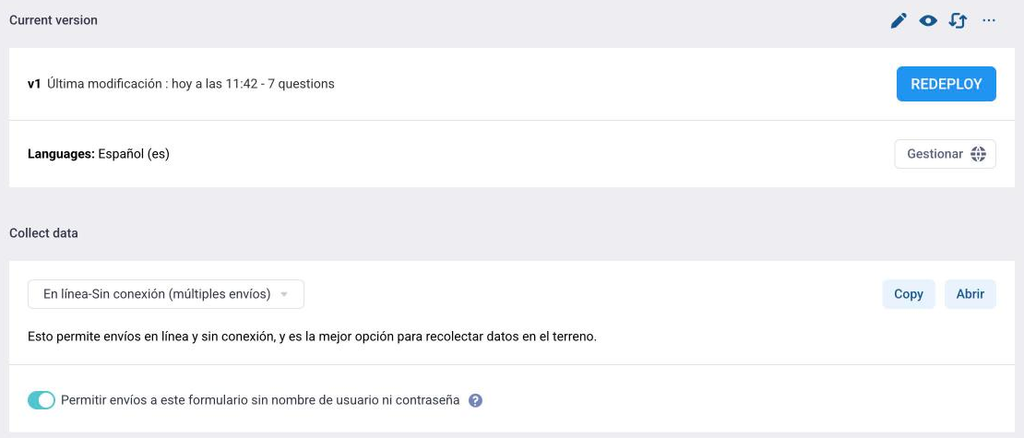

Botón Deploy

# 2. Cómo recolectar datos

## Tres maneras de responder

| Manera | Cuándo conviene |
| --- | --- |
| **Enlace web** | Lo más rápido: se abre en cualquier celular |
| **Código QR** | Igual que el enlace, sin escribir nada |
| **App KoboCollect** | Cuando **no hay internet** en el campo |

**Hoy usamos el QR**: se abre en el navegador del celular, sin instalar nada y sin crear ninguna cuenta.

## Primero: el enlace de la encuesta

En la página del proyecto → pestaña **FORMULARIO** → *Collect data*:

1. Dejar elegido **«En línea-Sin conexión (múltiples envíos)»**
2. **Copy** copia el enlace · **Abrir** lo abre para probarlo
3. Comprobar que está activo *«Permitir envíos a este formulario sin nombre de usuario ni contraseña»* — sin eso, pide cuenta

**Ese** es el enlace que se reparte: `ee.kobotoolbox.org/x/…`

## ¿Y el código QR?

**Kobo no genera el QR.** Da el enlace; el código lo hace uno.

- En **Chrome**: clic derecho en la página del formulario abierto → *Crear código QR* — sale del propio navegador, sin subir el enlace a nadie
- Sirve cualquier generador de QR de internet, **pero** ⚠️ es un tercero al que se le está entregando el enlace: para un formulario que no sea público, mejor no

Un código QR **es sólo el enlace dibujado**. Nada más.

## Ahora: respondan la encuesta

[figure not shown]

Código QR de la encuesta

**Dos minutos.** Los datos que analicemos después son los de ustedes.

## Recoger datos sin internet

- **KoboCollect** (Android, gratis) descarga el formulario una vez
- Se responde **sin señal**, en el aula o en la comunidad
- Al volver a tener internet: *Send Finalized Forms*

Esto es lo que hace a Kobo útil fuera de la ciudad.

## Ver las respuestas llegar

- **Datos → Tabla**: cada fila es una respuesta
- **Datos → Informes**: resúmenes automáticos
- El conteo se actualiza solo

## Así se ve: las respuestas llegando

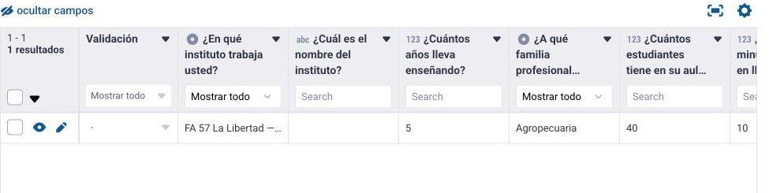

Tabla de datos en Kobo

# 3. Cómo descargar estos datos

## Bajar el archivo

1. Pestaña **DATOS** → **Descargas**
2. *Seleccionar el tipo de exportación*: **CSV**
3. *Formato de valores y encabezados*: **Valores y encabezados XML**
4. **Exportar** → aparece abajo, en **Exportaciones** → **Descargar**

El archivo cae en la carpeta de **Descargas**, con un nombre largo y con espacios. No hay que teclearlo nunca: ya veremos cómo.

## Así se ve: la pantalla de descarga

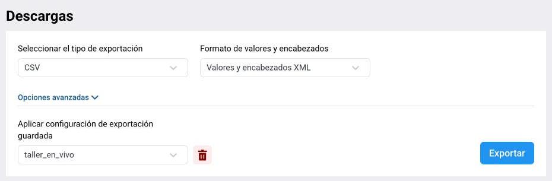

Pantalla de descarga

## Por qué CSV, y dos cuidados

Es **texto plano**: no depende de ningún programa, y va a seguir abriéndose dentro de diez años.

- **Los nombres de columna** son los nombres de variable que pusieron en Kobo — por eso importaba la regla 3
- ⚠️ **Si lo abren en Excel, las tildes van a salir raras** (`educaciÃ³n`). No está dañado: es la codificación. En Excel se arregla con *Datos → Obtener datos → Desde texto*, eligiendo **UTF-8**. En R no hace falta: ya lo dice la línea que vamos a correr

# Descanso

## Descanso — dos cosas opcionales, si quieren

**Su cuenta de Kobo** — para llevarse su propia copia del formulario:

1. **kf.kobotoolbox.org** → *Crear una cuenta*
2. Elegir **Servidor Global**
3. Confirmar el correo y entrar

## Así se ve: crear la cuenta

[figure not shown]

Crear una cuenta en KoboToolbox

## Descanso — y lo otro opcional

**R y RStudio en su propia laptop** — los dos instaladores, gratis:

- **R** → `cran.r-project.org` · **RStudio** → `posit.co/download`
- Se instalan en ese orden: primero R, después RStudio

# 4. Análisis estadístico sencillo

## R y RStudio

- **R** es el lenguaje; **RStudio** es la ventana donde se trabaja
- Gratis, y el estándar en investigación educativa
- La interfaz está en **inglés** — son unas diez palabras, las vemos sobre la marcha

## No vamos a escribir el código: vamos a recorrerlo

- Abrimos el archivo **`taller.R`**, que ya tiene todo escrito
- Cada línea se ejecuta con **Ctrl + Enter**
- Leer la línea → ejecutarla → mirar el resultado. En ese orden.

## Dónde correrlo — hoy y después

| En la del laboratorio | En la suya |
| --- | --- |
| **RStudio ya está instalado** | Instalarlo gratis: `cran.r-project.org` + `posit.co/download` |
| *File → Open* → `taller.R` | …o sin instalar nada: **posit.cloud** en el navegador |
| No necesita internet | `taller.R` es **el mismo archivo** en los dos casos |

Quien comparta máquina: **cambien de teclado después del descanso**, para que los dos escriban.

## Las cuatro ventanas de RStudio

- **Arriba a la izquierda:** el guion — `taller.R`, lo que vamos a recorrer
- **Abajo a la izquierda:** la consola — donde corre
- **Arriba a la derecha:** los datos cargados
- **Abajo a la derecha:** las gráficas

## Así se ve: las cuatro ventanas

[figure not shown]

Las cuatro ventanas

## De dónde salen los datos — se usa una, las otras quedan comentadas

```r
# Opción A: el archivo que descargaron (el más normal)
datos <- read.csv(file.choose(), sep = ";", fileEncoding = "UTF-8")

# Opción B: los datos de hoy, en vivo, por dirección web
# datos <- read.csv("https://kf.kobotoolbox.org/.../data.csv", ...)

# Opción C: datos de ejemplo, si no hay conexión
# datos <- read.csv("datos_ejemplo.csv", sep = ";", fileEncoding = "UTF-8")
```

Las tres leen **las mismas columnas**: cambiar de una a otra es mover un `#`.

Si faltan respuestas, **vuelve a correr la línea**: los datos entran en vivo.

## Abrir un CSV cualquiera — el suyo, el de otro

`file.choose()` **abre el buscador de archivos**: se hace clic en el archivo y listo.

```r
datos <- read.csv(file.choose(), sep = ";", fileEncoding = "UTF-8")
```

- No hay que escribir **ninguna ruta**
- No hay que saber en qué carpeta cayó la descarga
- Funciona igual en Windows, Mac y Linux

## El botón, si prefieren el ratón

*Environment* → **Import Dataset** → *From Text (base)…*

RStudio **escribe el código por ustedes** en la consola: se puede copiar al guion y ya queda escrito para la próxima.

## Mirar antes de calcular

```r
head(datos)     # las primeras filas
nrow(datos)     # cuántas respuestas hay
names(datos)    # cómo se llama cada columna
str(datos)      # qué tipo de dato hay en cada una
```

**Siempre mirar los datos antes de sacar conclusiones.**

## Kobo agrega columnas que no pedimos

```r
respuestas <- c("instituto", "anios_experiencia", "area",
                "estudiantes_aula", "minutos_traslado", "uso_celular")
datos <- datos[, respuestas]
```

- `_id`, `_uuid`, `_submission_time`… son columnas técnicas de Kobo
- Nos quedamos con **las seis respuestas** y seguimos

## Contar y promediar

```r
table(datos$area)                # cuántos por familia profesional
mean(datos$anios_experiencia)    # promedio de años enseñando
summary(datos$minutos_traslado)  # mínimo, mediana, máximo
```

`datos$area` significa “la columna *area* de la tabla *datos*”.

## Comparar grupos

```r
tapply(datos$minutos_traslado, datos$area, mean)
```

*“El promedio de traslado, separado por familia profesional.”*

Esta es la línea que más van a reutilizar.

## Cruzar dos preguntas

```r
table(datos$area, datos$uso_celular)
```

Una tabla de doble entrada: quiénes usan el celular, por área.

# 5. Cómo hacer gráficas

## Gráfico 1 — un gráfico de barras

```r
par(mar = c(5, 9, 4, 2))
barplot(table(datos$area),
        horiz = TRUE, las = 1, col = "steelblue",
        main = "Participantes por familia profesional")
```

`par(mar = ...)` amplía el margen izquierdo: los nombres son largos.

## Participantes por familia profesional

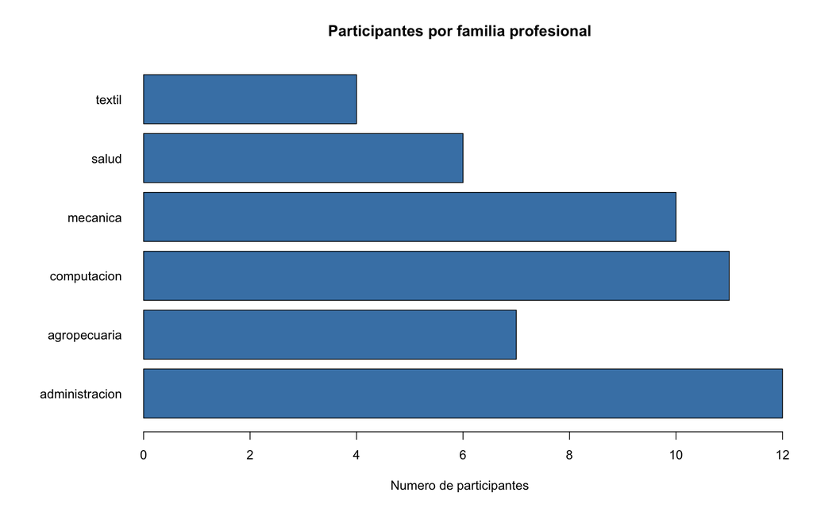

Participantes por familia profesional

## Gráfico 2 — un histograma

```r
hist(datos$anios_experiencia,
     breaks = 8, col = "steelblue",
     xlab = "Anios ensenando",
     main = "Experiencia docente")
```

## Experiencia docente

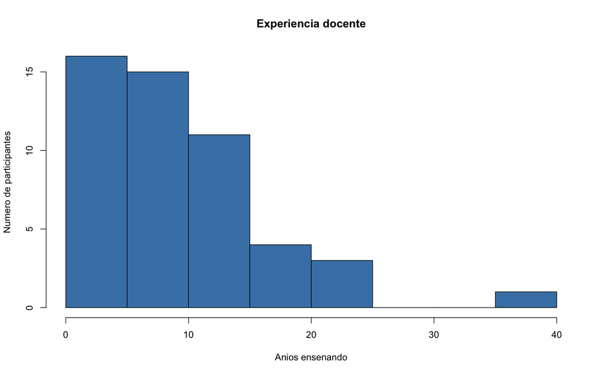

Experiencia docente

## Gráfico 3 — dos variables a la vez

```r
par(mar = c(9, 5, 4, 2))
boxplot(minutos_traslado ~ area,
        data = datos, col = "lightgray", las = 2,
        xlab = "", ylab = "Minutos de traslado")
```

La tilde `~` se lee **“según”**: el traslado *según* la familia profesional.

## Traslado al instituto según familia profesional

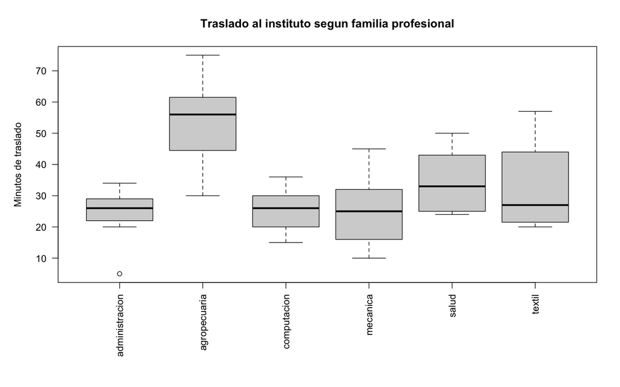

Traslado según familia profesional

## Y aquí aparece algo

- Cada caja es un grupo; la línea del medio es la **mediana**
- Con estos datos, **agropecuaria** demora bastante más que las demás
- Nadie preguntó eso: **salió de cruzar dos columnas**

⚠️ **Dos cautelas, y valen para siempre:**

- Son las respuestas de **quienes contestaron**, no de todos los docentes de la región
- Con pocos datos, una diferencia pequeña puede ser **casualidad**: fíjense si es **grande** y si **tiene sentido**

## ¿Ya terminaron? Tres cosas que hacer

1. **Ser tutor de su fila** — es lo más útil ahora mismo
2. **Cerrar el círculo ustedes solos:** clonar el formulario, cambiarle dos preguntas, desplegarlo, **responderlo desde su propio celular** y **descargar su CSV** — el suyo sí lo pueden descargar, porque es de ustedes
3. **Cambiarle algo a una gráfica:** el histograma con `estudiantes_aula`, o el `boxplot` con otra variable

## Guardar la gráfica

```r
png("mi_grafico.png", width = 1000, height = 700)
barplot(table(datos$area), horiz = TRUE, las = 1, col = "steelblue")
dev.off()

getwd()   # dónde quedó el archivo
```

Si están en el navegador, se descarga desde el panel *Files*.

## Todo el análisis en una pantalla

```r
datos <- read.csv("datos_ejemplo.csv", sep = ";", fileEncoding = "UTF-8")
datos <- datos[, respuestas]
table(datos$area)
mean(datos$anios_experiencia)
tapply(datos$minutos_traslado, datos$area, mean)
barplot(table(datos$area), horiz = TRUE, col = "steelblue")
```

**Seis líneas.** Eso es una encuesta analizada.

## Cómo se cuenta un hallazgo

**Una cifra · una gráfica · una frase.**

# 6. Cierre

## Ahora ustedes: su propia copia

Quien tenga cuenta, en diez minutos:

1. **Iniciar sesión** en Kobo y abrir el **enlace del proyecto** *(el de la diapositiva siguiente — no el que usaron para responder)*
2. Pestaña **FORMULARIO** → el botón **⋯** (*Otras acciones*), arriba a la derecha → **Clone this project**
3. Cambiarle **dos preguntas** a algo de su curso
4. **REDEPLOY** y probarla en su propio celular

## El enlace para clonar

[figure not shown]

Página del proyecto

**Primero inicien sesión**, y luego este código — o el enlace de la guía.

## Así se ve: Otras acciones → Clone

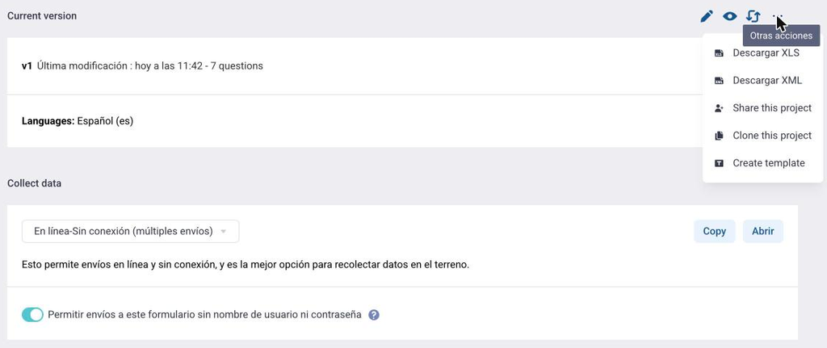

Clonar el proyecto

**⋯ Otras acciones** está en la pestaña *FORMULARIO*, a la derecha de *Current version*.

## Lo que se llevan hoy

- El **formulario de hoy**, listo para copiar y adaptar — el enlace está en la guía
- Quien haya creado cuenta: **su propia copia**, ya desplegada
- Dos hojas: la **guía** (el flujo y Kobo) y la **hoja de código** (las líneas de R)
- **`taller.R`** y **`datos_ejemplo.csv`** — el análisis completo, para repetirlo

## Para seguir practicando

- Copiar el formulario de hoy y cambiarle las preguntas
- Aplicarlo a algo propio: una encuesta de entrada a un curso, una evaluación de taller
- Volver a correr las mismas seis líneas

**El flujo es siempre el mismo; lo único que cambia son las preguntas.**

# ¿Y cuando surja una duda?

## Lo primero: R trae su propia ayuda

Sin internet, dentro de RStudio:

```r
?barplot           # la ayuda de una función
help(read.csv)     # lo mismo, escrito de otra forma
example(boxplot)   # ejemplos que se ejecutan solos
```

Y cuando algo falla: **copiar el mensaje de error tal cual** y buscarlo. Casi siempre alguien ya lo preguntó.

## Dónde preguntar

- **KoboToolbox** — `support.kobotoolbox.org` (manual) y `community.kobotoolbox.org` (foro; se pregunta y responde gente de verdad)
- **R** — `stackoverflow.com` y su versión en español, `es.stackoverflow.com`
- **Las hojas de referencia** de Posit: `posit.co/resources/cheatsheets`
- Y entre ustedes: **son quince instituciones** con los mismos problemas

## Preguntarle a una IA — sirve, con oficio

**ChatGPT, Claude, Gemini** — las tres tienen versión gratuita y responden en español.

Lo que cambia una respuesta inútil por una útil:

1. **Decir el contexto:** *«en R base, sin instalar paquetes, soy principiante»*
2. **Pegar el error completo**, no un resumen
3. **Pegar la salida de `str(datos)`** — así sabe cómo son sus datos
4. **Pedir que explique**, no sólo que arregle

## Dos advertencias, y van en serio

⚠️ **La IA se equivoca con seguridad.** Inventa funciones que no existen. No pasa nada: **se ejecuta y R avisa.** Nunca copiar sin correr.

🔴 **No peguen datos personales de sus estudiantes** — nombres, DNI, notas. Lo que se pega en un servicio ajeno sale del instituto. Para pedir ayuda basta con `str(datos)` o dos filas inventadas.

## Antes de las preguntas: tres para ustedes

- **¿Qué les resultó nuevo?** Algo que hoy descubrieron que se podía hacer.
- **¿Qué les confirmó lo que ya venían haciendo?** Algo que ya hacían y que ahora tiene un método y un nombre.
- **¿Qué preguntas se quedan sin responder?** Lo que querrían probar y todavía no saben cómo.

## Y por escrito — dos minutos

[figure not shown]

Encuesta de salida

Las mismas preguntas, más **qué quiere investigar en su instituto**.

## Lo que les llega por correo

A quien haya dejado su correo en la lista:

- **`taller.R`** y `datos_ejemplo.csv` — para repetir el análisis
- La **guía** y la **hoja de código** en PDF
- La **constancia de participación**, que emite Fe y Alegría
- Y, a quien lo haya marcado en la encuesta de salida, **noticias si se organiza un taller más largo**

## Preguntas y respuestas

**Gracias.**

Stephen Pitts, S.J. — Marquette University